# Analyse statistique descriptive

Effectifs, profils, établissements, territoires et ratios de mouvement

Auteur·rice

Projet DEPP A5 Mobilité des personnels

Date de publication

22 septembre 2026

**ImportantPortée**

Cette étape est exclusivement descriptive. Elle décrit les agrégats publiés et n’établit aucun effet causal. Les différences entre degrés, territoires ou catégories peuvent refléter la composition, le champ, la couverture, les nomenclatures ou d’autres facteurs non observés.

# 1 Concepts statistiques

| Concept | Usage dans ce document |
| --- | --- |
| **Effectif** | somme d’ETP ou nombre d’établissements observés |
| **Proportion** | part d’un effectif dans un total explicitement défini |
| **Taux** | rapport rapporté à une population exposée ; aucun taux individuel de mobilité n’est disponible |
| **Variation** | différence ou évolution relative entre deux millésimes comparables |
| **Écart** | différence descriptive entre groupes, sans interprétation causale |

# 2 Effectifs et évolutions

Effectifs d'établissements et d'enseignants

| Année | Établissements | ETP enseignants | Degré | Variation en ETP | Variation relative |
| --- | --- | --- | --- | --- | --- |
| 2024 | 47 507,0 | 316 886,5 | Premier degré | NA | NA |
| 2025 | 47 077,0 | 314 691,5 | Premier degré | −2 195,0 | −0.69% |
| 2024 | 10 697,0 | 441 452,9 | Second degré | NA | NA |

Source : DEPP, indicateurs de personnels 1D et 2D. Le second degré ne comporte qu'un millésime.

Entre 2024 et 2025, le premier degré passe de 316 886,5 à 314 691,5 ETP, soit une variation de −2 195 ETP (−0,69 %). Ce constat décrit les établissements couverts ; il ne mesure ni des départs nets ni des mobilités individuelles.

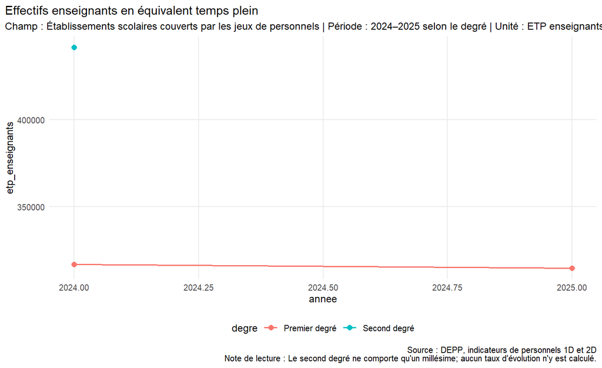

# 3 Profils par âge

| Année | Classe d'âge | Proportion d'ETP | Couverture du dénominateur |
| --- | --- | --- | --- |
| Premier degré |  |  |  |
| 2025 | Moins de 35 ans | 19.4% | 82.1% |
| 2024 | Moins de 35 ans | 19.8% | 82.0% |
| 2025 | 35 à 49 ans | 45.5% | 82.1% |
| 2024 | 35 à 49 ans | 46.9% | 82.0% |
| 2025 | 50 ans ou plus | 35.2% | 82.1% |
| 2024 | 50 ans ou plus | 33.3% | 82.0% |
| Second degré |  |  |  |
| 2024 | Moins de 35 ans | 16.5% | 100.0% |
| 2024 | 35 à 49 ans | 40.5% | 100.0% |
| 2024 | 50 ans ou plus | 43.0% | 100.0% |

Source : DEPP. Les cellules masquées par le secret statistique restent exclues du dénominateur correspondant.

Le premier degré présente une couverture d’environ 82 % des ETP pour les classes d’âge, contre 100 % dans le second degré. Les proportions du premier degré ne doivent donc pas être comparées sans tenir compte de cette couverture.

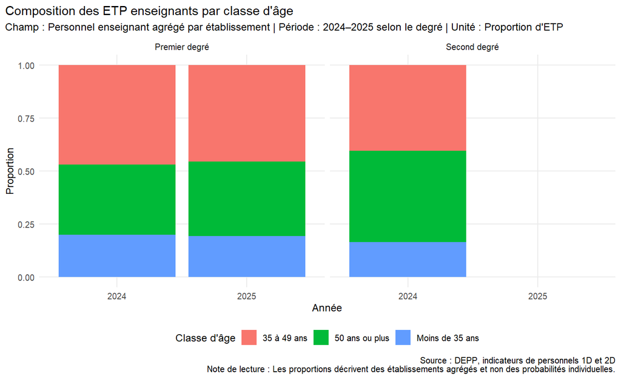

# 4 Ancienneté dans l’établissement

| Année | Ancienneté établissement | Proportion d'ETP | Couverture |
| --- | --- | --- | --- |
| Premier degré |  |  |  |
| 2025 | Moins de 2 ans | 27.0% | 82.1% |
| 2024 | Moins de 2 ans | 27.9% | 82.0% |
| 2025 | 2 à 4 ans | 19.7% | 82.1% |
| 2024 | 2 à 4 ans | 19.4% | 82.0% |
| 2025 | 5 à 7 ans | 14.7% | 82.1% |
| 2024 | 5 à 7 ans | 15.3% | 82.0% |
| 2025 | 8 ans ou plus | 38.7% | 82.1% |
| 2024 | 8 ans ou plus | 37.5% | 82.0% |
| Second degré |  |  |  |
| 2024 | Moins de 2 ans | 22.5% | 100.0% |
| 2024 | 2 à 4 ans | 16.2% | 100.0% |
| 2024 | 5 à 7 ans | 12.7% | 100.0% |
| 2024 | 8 ans ou plus | 48.6% | 100.0% |

Source : DEPP. L'ancienneté dans l'établissement n'est pas l'ancienneté de carrière.

Dans le champ couvert, la part des ETP présents depuis huit ans ou plus atteint 38,7 % dans le premier degré en 2025 et 48,6 % dans le second degré en 2024. Ces parts constituent des profils agrégés, pas des probabilités individuelles de stabilité.

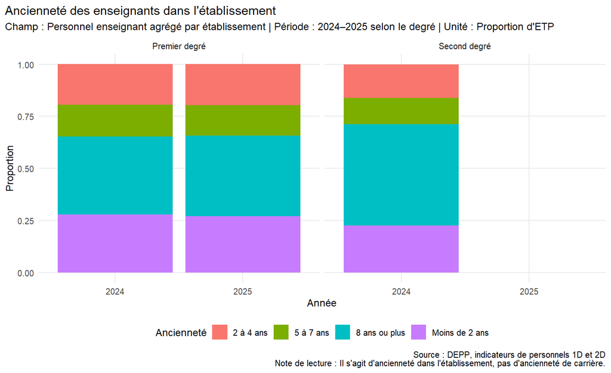

# 5 Corps et grade

| Année | ETP | Groupe de corps | Part |
| --- | --- | --- | --- |
| 2024 | 55 202,8 | Agrégés | 12.5% |
| 2024 | 273 329,3 | Certifiés et PEPS | 61.9% |
| 2024 | 56 909,7 | PLP | 12.9% |
| 2024 | 10 466,5 | Autres corps titulaires | 2.4% |
| 2024 | 45 544,6 | Non-titulaires | 10.3% |

Source : DEPP, personnels du second degré. Groupes agrégés au niveau établissement.

Les certifiés et PEPS représentent 61,9 % des ETP ventilés par groupe de corps en 2024. Le **grade individuel est absent** des données publiques acquises : il n’est ni décrit ni reconstitué.

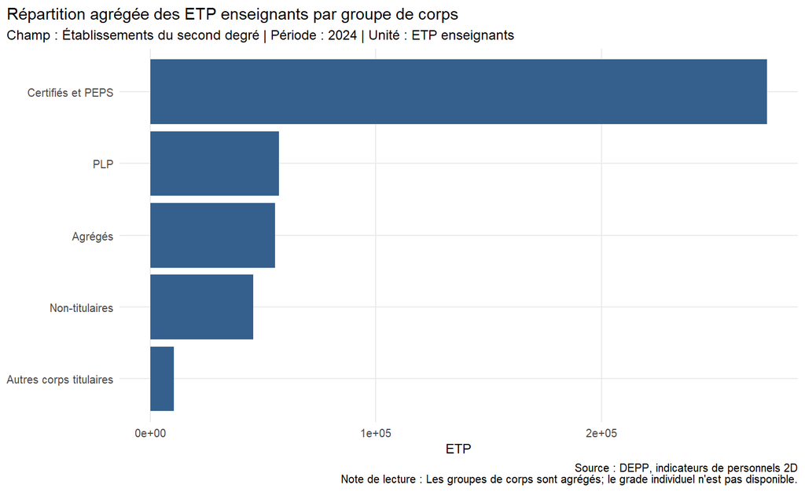

# 6 Établissements

| Année | Minimum | Q1 | Médiane | Q3 | P90 | Maximum |
| --- | --- | --- | --- | --- | --- | --- |
| Premier degré |  |  |  |  |  |  |
| 2025 | 0,0 | 3,0 | 5,2 | 9,0 | 14,0 | 60,0 |
| 2024 | 0,5 | 3,0 | 5,2 | 8,8 | 14,0 | 59,8 |
| Second degré |  |  |  |  |  |  |
| 2024 | 4,4 | 24,3 | 34,5 | 48,1 | 77,4 | 250,0 |

Source : DEPP. Unité : ETP enseignants par établissement.

La médiane s’établit à 5,2 ETP dans le premier degré et à 34,5 ETP dans le second degré. Cet écart reflète notamment des structures d’établissement différentes ; il ne constitue pas un résultat sur leur efficacité.

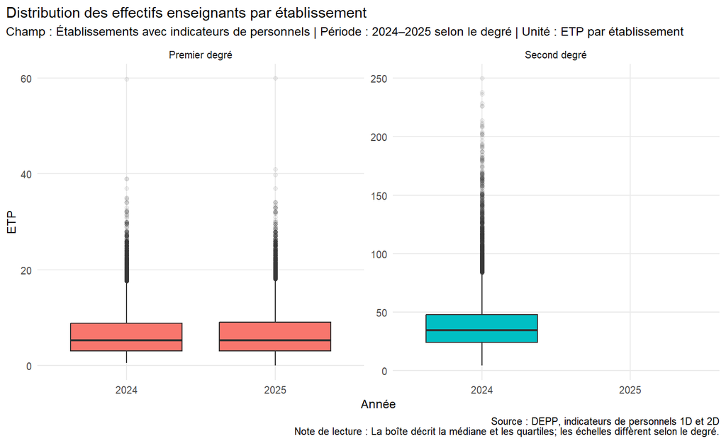

# 7 Territoires

| Année | Code | Département | Établissements | ETP enseignants |
| --- | --- | --- | --- | --- |
| 2025 | 59 | Nord | 1 771,0 | 13 217,1 |
| 2025 | 93 | Seine-Saint-Denis | 896,0 | 10 541,7 |
| 2025 | 13 | Bouches-du-Rhône | 1 199,0 | 10 059,0 |
| 2025 | 69 | Rhône | 986,0 | 9 306,4 |
| 2025 | 95 | Val-d'Oise | 792,0 | 7 708,4 |
| 2025 | 77 | Seine-et-Marne | 1 085,0 | 7 504,7 |
| 2025 | 91 | Essonne | 839,0 | 7 419,9 |
| 2025 | 78 | Yvelines | 966,0 | 7 366,2 |
| 2025 | 75 | Paris | 728,0 | 7 312,9 |
| 2025 | 62 | Pas-de-Calais | 1 258,0 | 7 238,0 |
| 2025 | 33 | Gironde | 964,0 | 7 111,0 |
| 2025 | 92 | Hauts-de-Seine | 627,0 | 7 081,5 |
| 2025 | 94 | Val-de-Marne | 650,0 | 6 906,6 |
| 2025 | 44 | Loire-Atlantique | 791,0 | 6 617,2 |
| 2025 | 974 | La Réunion | 522,0 | 6 254,4 |

Source : DEPP, premier degré, 2025. Classement sur des effectifs, non sur des taux.

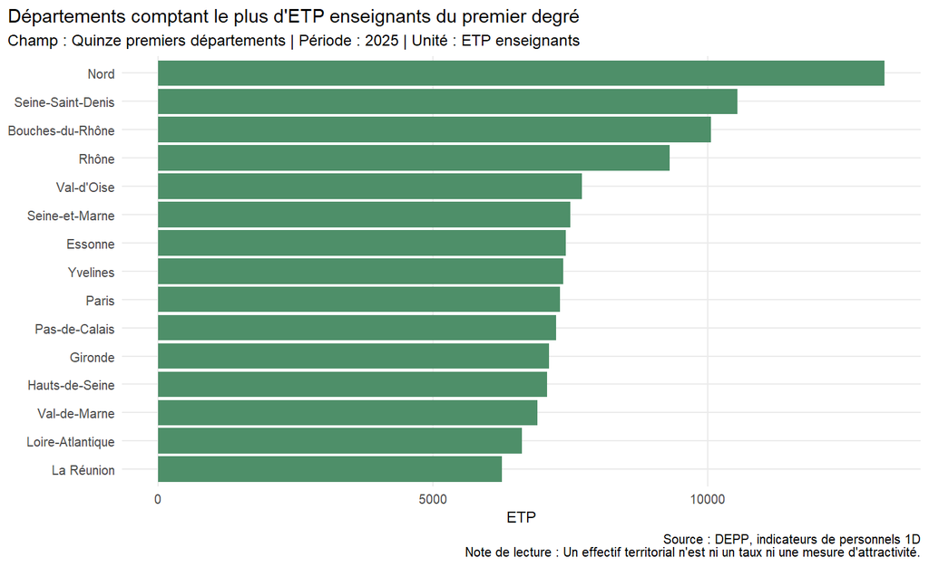

# 8 Éducation prioritaire

| Année | Éducation prioritaire | Établissements | ETP enseignants | Part des ETP |
| --- | --- | --- | --- | --- |
| Premier degré |  |  |  |  |
| 2025 | Hors EP (snapshot) | 40 177,0 | 242 954,8 | 77.6% |
| 2025 | REP ou REP+ | 6 510,0 | 70 318,5 | 22.4% |
| 2024 | Hors EP (snapshot) | 40 146,0 | 243 075,0 | 77.5% |
| 2024 | REP ou REP+ | 6 486,0 | 70 598,9 | 22.5% |
| Second degré |  |  |  |  |
| 2024 | Hors EP (snapshot) | 9 572,0 | 396 894,1 | 90.0% |
| 2024 | REP ou REP+ | 1 094,0 | 43 886,7 | 10.0% |

Sources : DEPP et Annuaire de l'éducation. Statut EP issu du snapshot 2026.

Le groupe REP ou REP+ représente environ 22,5 % des ETP appariés du premier degré et 10,0 % de ceux du second degré. Le décalage entre le millésime des personnels et le snapshot 2026 interdit une lecture historique certaine.

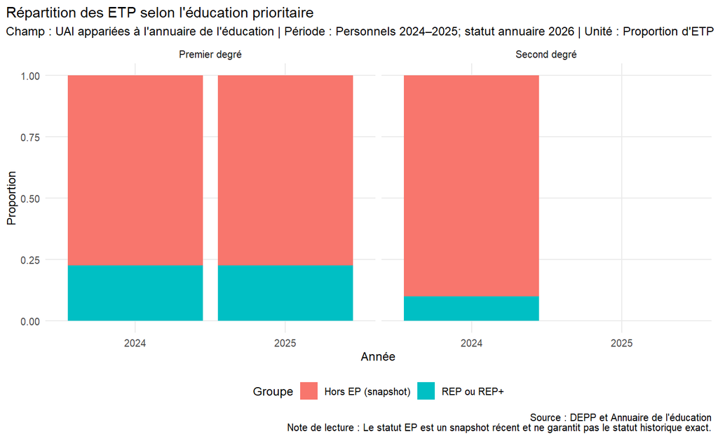

# 9 Mobilités : ce que les données permettent

| Année | Ratio publié | Départements | Moyenne | Q1 | Médiane | Q3 | Minimum | Maximum |
| --- | --- | --- | --- | --- | --- | --- | --- | --- |
| 2019 | pression_demandes_entree_sortie | 101 | 3,73 | 0,47 | 1,32 | 4,12 | 0,01 | 48,33 |
| 2019 | ratio_sorties_realisees_demandees | 101 | 0,41 | 0,23 | 0,37 | 0,55 | 0,06 | 1,00 |
| 2019 | ratio_entrees_sorties_realisees | 101 | 1,33 | 0,88 | 1,09 | 1,43 | 0,11 | 6,52 |

Source : DGRH-DEPP, mouvement interdépartemental du premier degré public, 2019.

La forte différence entre moyenne et médiane du ratio de pression des demandes d’entrée traduit une distribution très asymétrique. Ces mesures sont des **ratios départementaux**, pas des taux individuels. Elles ne permettent pas de décrire les changements d’établissement, de fonction ou les sorties véritables.

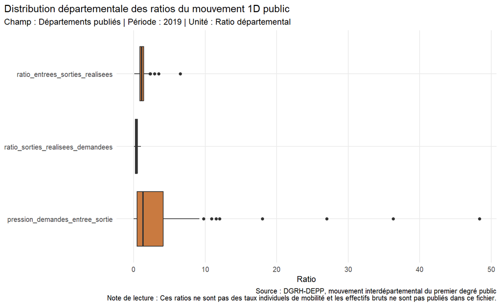

Les 84 apparitions et 514 disparitions apparentes d’UAI décrites à l’étape 7 restent des événements de présence dans le fichier. Elles ne sont pas ajoutées aux ratios de mobilité.

# 10 Validation

Validation des sorties descriptives

| INDICATEUR | RESULTAT | SEUIL | STATUT | ACTION |
| --- | --- | --- | --- | --- |
| Effectifs non négatifs | 0 | 0 | OK | Aucune |
| Proportions d'âge bornées | 0 | 0 | OK | Aucune |
| Proportions d'ancienneté bornées | 0 | 0 | OK | Aucune |
| Clé territoires | 0 | 0 | OK | Aucune |
| Figures produites | 0 | 0 | OK | Aucune |
| Grade individuel non inventé | 0 | 0 | OK | Aucune |

Les contrôles vérifient la non-négativité des effectifs, le bornage des proportions, l’unicité territoriale, la production des graphiques et l’absence de grade individuel fabriqué.